```python
# Run this cell to set up packages for lecture.
from lec06_imports import *
```

# Lecture 6 – Grouping and Data Visualization 📈

## DSC 10, Winter 2024

### Announcements

- Quiz 1 is **today in discussion section**.
  - It is a 20 minute paper-based quiz administered at the beginning of discussion.
    - Afterwards, the TA can help with Homework 1 questions
  - Seats are assigned. Search your email for **DSC 10 Quiz 1 Seating Assignment** or look up your seat [here](https://edstem.org/us/courses/51231/discussion/4157768).
- Homework 1 is due **Thursday at 11:59PM**.
- Make sure to try the "challenge problems" at the end of Friday's lecture and watch [this](https://www.youtube.com/watch?v=xg7rnjWnZ48) walkthrough video for solutions.

### Agenda

- Grouping.
- Why visualize?
- Terminology.
- Scatter plots.
- Line plots.
- Bar charts.

### Aside: Keyboard shortcuts

There are several keyboard shortcuts built into Jupyter Notebooks designed to help you save time. To see them, either click the keyboard button in the toolbar above or hit the H key on your keyboard (as long as you're not actively editing a cell).

Particularly useful shortcuts:

| Action | Keyboard shortcut |
| --- | --- |
| Run cell + jump to next cell | SHIFT + ENTER |
| Save the notebook | CTRL/CMD + S |
| Create new cell above/below | A/B |
| Delete cell | DD |

## Grouping

### Question: Which region is the most populated?

```python
states = bpd.read_csv('data/states.csv').set_index('State')
states = states.assign(Density=states.get('Population') / states.get('Land Area'))
states
```

| State | Region | Capital City | Population | Land Area | Party | Density |
| --- | --- | --- | --- | --- | --- | --- |
| Alabama | South | Montgomery | 5024279 | 50645 | Republican | 99.21 |
| Alaska | West | Juneau | 733391 | 570641 | Republican | 1.29 |
| Arizona | West | Phoenix | 7151502 | 113594 | Republican | 62.96 |
| ... | ... | ... | ... | ... | ... | ... |
| West Virginia | South | Charleston | 1793716 | 24038 | Republican | 74.62 |
| Wisconsin | Midwest | Madison | 5893718 | 54158 | Republican | 108.82 |
| Wyoming | West | Cheyenne | 576851 | 97093 | Republican | 5.94 |

50 rows × 6 columns

### Organizing states by region

We can find the total population of any one region using the tools we already have.

```python
states[states.get('Region') == 'West'].get('Population').sum()
```

```
78588572
```

```python
states[states.get('Region') == 'Midwest'].get('Population').sum()
```

```
68985454
```

But can we find the total population of **every** region all at the same time, without writing very similar code multiple times? Yes, there is a better way!

### A new method: `.groupby`

Observe what happens when we use the `.groupby` method on `states` with the argument `'Region'`.

```python
states.groupby('Region').sum()
```

| Region | Population | Land Area | Density |
| --- | --- | --- | --- |
| Midwest | 68985454 | 750524 | 1298.78 |
| Northeast | 57609148 | 161912 | 4957.49 |
| South | 125576562 | 868356 | 3189.37 |
| West | 78588572 | 1751054 | 881.62 |

These populations (for the `'West'` and `'Midwest'`) match the ones we found on the previous slide, except now we get the populations for all regions at the same time. What just happened? 🤯

### An illustrative example: Pets 🐱 🐶🐹

Consider the DataFrame `pets`, shown below.

|  | Species | Color | Weight | Age |
| --- | --- | --- | --- | --- |
| 0 | dog | black | 40 | 5.0 |
| 1 | cat | golden | 15 | 8.0 |
| 2 | cat | black | 20 | 9.0 |
| 3 | dog | white | 80 | 2.0 |
| 4 | dog | golden | 25 | 0.5 |
| 5 | hamster | golden | 1 | 3.0 |

Let's see what happens under the hood when we run `pets.groupby('Species').mean()`.

```python
show_grouping_animation()
```

[interactive chart not shown]

### Let's try it out!

```python
pets = bpd.DataFrame().assign(
    Species=['dog', 'cat', 'cat', 'dog', 'dog', 'hamster'],
    Color=['black', 'golden', 'black', 'white', 'golden', 'golden'],
    Weight=[40, 15, 20, 80, 25, 1],
    Age=[5, 8, 9, 2, 0.5, 3]
)
pets
```

|  | Species | Color | Weight | Age |
| --- | --- | --- | --- | --- |
| 0 | dog | black | 40 | 5.0 |
| 1 | cat | golden | 15 | 8.0 |
| 2 | cat | black | 20 | 9.0 |
| 3 | dog | white | 80 | 2.0 |
| 4 | dog | golden | 25 | 0.5 |
| 5 | hamster | golden | 1 | 3.0 |

```python
pets.groupby('Species').mean()
```

| Species | Weight | Age |
| --- | --- | --- |
| cat | 17.50 | 8.5 |
| dog | 48.33 | 2.5 |
| hamster | 1.00 | 3.0 |

It takes several steps to go from the original `pets` DataFrame to this grouped DataFrame, but we don't get to see any of Python's inner workings, just the final output.

### Back to states: which region is most populated?

```python
states.groupby('Region').sum()
```

| Region | Population | Land Area | Density |
| --- | --- | --- | --- |
| Midwest | 68985454 | 750524 | 1298.78 |
| Northeast | 57609148 | 161912 | 4957.49 |
| South | 125576562 | 868356 | 3189.37 |
| West | 78588572 | 1751054 | 881.62 |

```python
# Note the use of .index – remember, the index isn't a column!
(
    states
    .groupby('Region')
    .sum()
    .sort_values(by='Population', ascending=False)
    .index[0]
)
```

```
'South'
```

### Using `.groupby` in general

In short, `.groupby` aggregates (collects) all rows with the same value in a specified column (e.g. `'Region'`) into a single row in the resulting DataFrame, using an aggregation method (e.g. `.sum()`) to combine values from different rows with the same value in the specified column.

To use `.groupby`:

1. **Choose a column to group by**.
   - `.groupby(column_name)` will gather rows which have the same value in the specified column (`column_name`).
   - In the resulting DataFrame, there will be one row for every unique value in that column.
1. **Choose an aggregation method**.
   - The aggregation method will be applied **within** each group.
   - The aggregation method is applied individually to each column.
     - If it doesn't make sense to use the aggregation method on a column, the column is dropped from the output.
   - Common aggregation methods include `.count()`, `.sum()`, `.mean()`, `.median()`, `.max()`, and `.min()`.

### Observations on grouping

1. After grouping, the index changes. The new row labels are the *group labels* (i.e., the unique values in the column that we grouped on), sorted in ascending order.

```python
states
```

| State | Region | Capital City | Population | Land Area | Party | Density |
| --- | --- | --- | --- | --- | --- | --- |
| Alabama | South | Montgomery | 5024279 | 50645 | Republican | 99.21 |
| Alaska | West | Juneau | 733391 | 570641 | Republican | 1.29 |
| Arizona | West | Phoenix | 7151502 | 113594 | Republican | 62.96 |
| ... | ... | ... | ... | ... | ... | ... |
| West Virginia | South | Charleston | 1793716 | 24038 | Republican | 74.62 |
| Wisconsin | Midwest | Madison | 5893718 | 54158 | Republican | 108.82 |
| Wyoming | West | Cheyenne | 576851 | 97093 | Republican | 5.94 |

50 rows × 6 columns

```python
states.groupby('Region').sum()
```

| Region | Population | Land Area | Density |
| --- | --- | --- | --- |
| Midwest | 68985454 | 750524 | 1298.78 |
| Northeast | 57609148 | 161912 | 4957.49 |
| South | 125576562 | 868356 | 3189.37 |
| West | 78588572 | 1751054 | 881.62 |

1. The aggregation method is applied separately to each column. If it does not make sense to apply the aggregation method to a certain column, the column will disappear. 🐇🎩
1. Since the aggregation method is applied to each column **separately**, the rows of the resulting DataFrame need to be interpreted with care.

```python
states.groupby('Region').max()
```

| Region | Capital City | Population | Land Area | Party | Density |
| --- | --- | --- | --- | --- | --- |
| Midwest | Topeka | 12812508 | 81759 | Republican | 288.77 |
| Northeast | Trenton | 20201249 | 47126 | Republican | 1263.12 |
| South | Tallahassee | 29145505 | 261232 | Republican | 636.37 |
| West | Santa Fe | 39538223 | 570641 | Republican | 253.81 |

```python
12812508 / 81759 == 288.77
```

```
False
```

1. The column names don't make sense after grouping with the `.count()` aggregation method.

```python
states.groupby('Region').count()
```

| Region | Capital City | Population | Land Area | Party | Density |
| --- | --- | --- | --- | --- | --- |
| Midwest | 12 | 12 | 12 | 12 | 12 |
| Northeast | 9 | 9 | 9 | 9 | 9 |
| South | 16 | 16 | 16 | 16 | 16 |
| West | 13 | 13 | 13 | 13 | 13 |

### Dropping, renaming, and reordering columns

Consider dropping unneeded columns and renaming columns as follows:

1. Use `.assign` to create a new column containing the same values as the old column(s).
2. Use `.drop(columns=list_of_column_labels)` to drop the old column(s).
   - Alternatively, use `.get(list_of_column_labels)` to keep only the columns in the given list. The columns will appear in the order you specify, so this is also useful for reordering columns!

```python
states_by_region = states.groupby('Region').count()
states_by_region = states_by_region.assign(
                    States=states_by_region.get('Capital City')
                    ).get(['States'])
states_by_region
```

| Region | States |
| --- | --- |
| Midwest | 12 |
| Northeast | 9 |
| South | 16 |
| West | 13 |

## Why visualize?

### Little Women

In Lecture 1, we were able to answer questions about the plot of *Little Women* without having to read the novel and without having to understand Python code. Some of those questions included:

- Who is the main character?
- Which pair of characters gets married in Chapter 35?

We answered these questions from a data visualization alone!

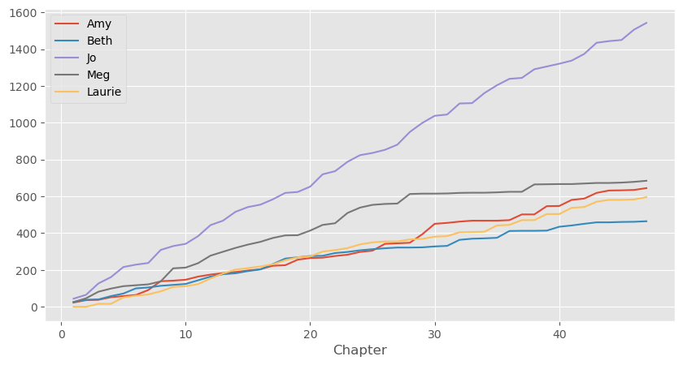

```python
bpd.read_csv('data/lw_counts.csv').plot(x='Chapter');
```

### Napoleon's March

> "Probably the best statistical graphic ever drawn, this map by Charles Joseph Minard portrays the losses suffered by Napoleon's army in the Russian campaign of 1812." ([source](https://www.edwardtufte.com/tufte/posters))

[figure not shown]

### Why visualize?

- Computers are better than humans at crunching numbers, but humans are better at identifying visual patterns.
- Visualizations allow us to understand lots of data quickly – they make it easier to spot trends and communicate our results with others.
- There are many types of visualizations; in this class, we'll look at scatter plots, line plots, bar charts, and histograms, but there are many others.
  - The right choice depends on the type of data.

## Terminology

### Individuals and variables

[figure not shown]

- **Individual (row)**: Person/place/thing for which data is recorded. Also called an **observation**.
- **Variable (column)**: Something that is recorded for each individual. Also called a **feature**.

### Types of variables

There are two main types of variables:

- **Numerical**: It makes sense to do arithmetic with the values.
- **Categorical**: Values fall into categories, that may or may not have some *order* to them.

Note that here, "variable" does not mean a variable in Python, but rather it means a column in a DataFrame.

### Examples of numerical variables

- Salaries of NBA players 🏀.
  - Individual: An NBA player.
  - Variable: Their salary.
- Company's annual profit 💰.
  - Individual: A company.
  - Variable: Its annual profit.
- Flu shots administered per day 💉.
  - Individual: Date.
  - Variable: Number of flu shots administered on that date.

### Examples of categorical variables

- Movie genres 🎬.
  - Individual: A movie.
  - Variable: Its genre.
- Zip codes 🏠.
  - Individual: US resident.
  - Variable: Zip code.
    - Even though they look like numbers, zip codes are categorical (arithmetic doesn't make sense).
- Level of prior programming experience for students in DSC 10 🧑‍🎓.
  - Individual: Student in DSC 10.
  - Variable: Their level of prior programming experience, e.g. none, low, medium, or high.
    - There is an *order* to these categories!

### Concept Check ✅ – Answer at cc.dsc10.com

Which of these is **not** a numerical variable?

A. Fuel economy in miles per gallon.

B. Number of quarters at UCSD.

C. College at UCSD (Sixth, Seventh, etc).

D. Bank account number.

E. More than one of these are not numerical variables.

### Types of visualizations

The type of visualization we create depends on the kinds of variables we're visualizing.

- **Scatter plot**: Numerical vs. numerical.
- **Line plot**: Sequential numerical (time) vs. numerical.
- **Bar chart**: Categorical vs. numerical.
- **Histogram**: Numerical.
  - Will cover next time.

We may interchange the words "plot", "chart", and "graph"; they all mean the same thing.

## Scatter plots

### The data: exoplanets discovered by NASA 🪐

An [exoplanet](https://exoplanets.nasa.gov/what-is-an-exoplanet/overview/) is a planet outside our solar system. NASA has discovered over 5,000 exoplanets so far in its [search for signs of life beyond Earth](https://exoplanets.nasa.gov/search-for-life/big-questions/). 👽

[output not shown]

```python
exo = bpd.read_csv('data/exoplanets.csv').set_index('Name')
exo
```

| Name | Distance | Magnitude | Type | Year | Detection | Mass | Radius |
| --- | --- | --- | --- | --- | --- | --- | --- |
| 11 Comae Berenices b | 304.0 | 4.72 | Gas Giant | 2007 | Radial Velocity | 6165.90 | 11.88 |
| 11 Ursae Minoris b | 409.0 | 5.01 | Gas Giant | 2009 | Radial Velocity | 4684.81 | 11.99 |
| 14 Andromedae b | 246.0 | 5.23 | Gas Giant | 2008 | Radial Velocity | 1525.58 | 12.65 |
| ... | ... | ... | ... | ... | ... | ... | ... |
| YZ Ceti b | 12.0 | 12.07 | Terrestrial | 2017 | Radial Velocity | 0.70 | 0.91 |
| YZ Ceti c | 12.0 | 12.07 | Super Earth | 2017 | Radial Velocity | 1.14 | 1.05 |
| YZ Ceti d | 12.0 | 12.07 | Super Earth | 2017 | Radial Velocity | 1.09 | 1.03 |

5043 rows × 7 columns

### Scatter plots

- What is the relationship between `'Distance'` and `'Magnitude'`?

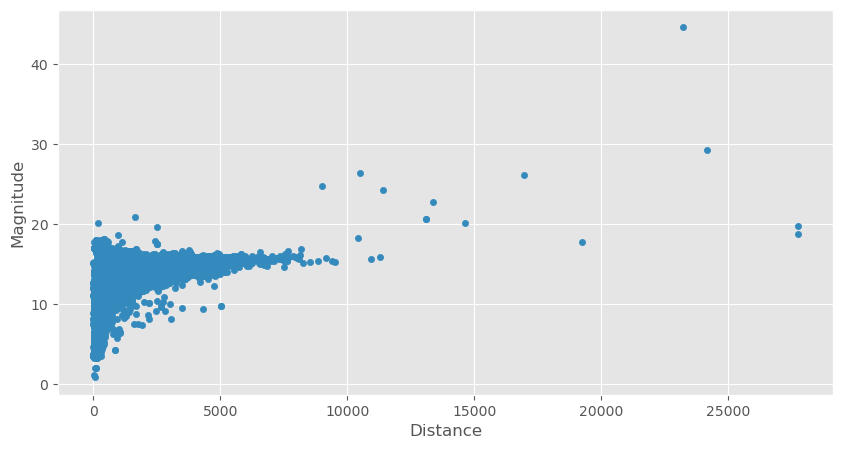

```python
exo.plot(kind='scatter', x='Distance', y='Magnitude');
```

- Further planets have greater `'Magnitude'` (meaning they are less bright), which makes sense.
- The data appears curved because `'Magnitude'` is measured on a logarithmic scale. A decrease of one unit in `'Magnitude'` corresponds to a 2.5 times increase in brightness.

[figure not shown]

### Scatter plots

- Scatter plots visualize the relationship between two numerical variables.
- To create one from a DataFrame `df`, use

  ```
  df.plot(
    kind='scatter',
    x=x_column_for_horizontal,
    y=y_column_for_vertical
  )
  ```

- The resulting scatter plot has one point per row of `df`.
- If you put a semicolon after a call to `.plot`, it will hide the weird text output that displays.

### Zooming in 🔍

The majority of exoplanets are less than 10,000 light years away; if we'd like to zoom in on just these exoplanets, we can query before plotting.

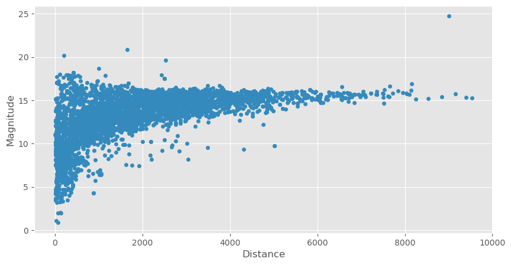

```python
exo[exo.get('Distance') < 10000].plot(kind='scatter', x='Distance', y='Magnitude');
```

## Line plots 📉

### Line plots

- How has the `'Magnitude'` of newly discovered exoplanets changed over time?

```python
# There were multiple exoplanets discovered each year.
# What operation can we apply to this DataFrame so that there is one row per year?
exo
```

| Name | Distance | Magnitude | Type | Year | Detection | Mass | Radius |
| --- | --- | --- | --- | --- | --- | --- | --- |
| 11 Comae Berenices b | 304.0 | 4.72 | Gas Giant | 2007 | Radial Velocity | 6165.90 | 11.88 |
| 11 Ursae Minoris b | 409.0 | 5.01 | Gas Giant | 2009 | Radial Velocity | 4684.81 | 11.99 |
| 14 Andromedae b | 246.0 | 5.23 | Gas Giant | 2008 | Radial Velocity | 1525.58 | 12.65 |
| ... | ... | ... | ... | ... | ... | ... | ... |
| YZ Ceti b | 12.0 | 12.07 | Terrestrial | 2017 | Radial Velocity | 0.70 | 0.91 |
| YZ Ceti c | 12.0 | 12.07 | Super Earth | 2017 | Radial Velocity | 1.14 | 1.05 |
| YZ Ceti d | 12.0 | 12.07 | Super Earth | 2017 | Radial Velocity | 1.09 | 1.03 |

5043 rows × 7 columns

- Let's calculate the average `'Magnitude'` of all exoplanets discovered in each `'Year'`.

```python
exo.groupby('Year').mean()
```

| Year | Distance | Magnitude | Mass | Radius |
| --- | --- | --- | --- | --- |
| 1995 | 50.00 | 5.45 | 146.20 | 13.97 |
| 1996 | 51.33 | 5.12 | 1020.67 | 13.09 |
| 1997 | 57.00 | 5.41 | 332.10 | 13.53 |
| ... | ... | ... | ... | ... |
| 2021 | 1944.22 | 13.01 | 255.42 | 4.44 |
| 2022 | 508.61 | 10.62 | 943.16 | 6.77 |
| 2023 | 451.89 | 12.09 | 162.78 | 7.12 |

29 rows × 4 columns

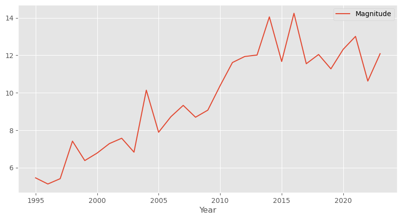

```python
exo.groupby('Year').mean().plot(kind='line', y='Magnitude');
```

- It looks like the brightest planets were discovered first, which makes sense.
- NASA's Kepler space telescope began its nine-year mission in 2009, leading to a boom in the discovery of exoplanets.

### Line plots

- Line plots show trends in numerical variables over time.
- To create one from a DataFrame `df`, use

  ```
  df.plot(
    kind='line',
    x=x_column_for_horizontal,
    y=y_column_for_vertical
  )
  ```

- To use the index as the x-axis, omit the `x=` argument.
  - This doesn't work for scatterplots, but it works for most other plot types.

### Extra video on line plots

If you're curious how line plots work under the hood, watch [this video](https://www.youtube.com/watch?v=glzZ04D1kDg) we made a few quarters ago.

```python
YouTubeVideo('glzZ04D1kDg')
```

[video not shown]

## Bar charts 📊

### Bar charts

- How big are each of the different `'Type'`s of exoplanets, on average?

```python
types = exo.groupby('Type').mean()
types
```

| Type | Distance | Magnitude | Year | Mass | Radius |
| --- | --- | --- | --- | --- | --- |
| Gas Giant | 1096.40 | 10.30 | 2013.73 | 1472.39 | 12.74 |
| Neptune-like | 2189.02 | 13.52 | 2016.59 | 15.28 | 3.11 |
| Super Earth | 1916.26 | 13.85 | 2016.43 | 5.81 | 1.58 |
| Terrestrial | 1373.60 | 13.45 | 2016.37 | 1.62 | 0.85 |

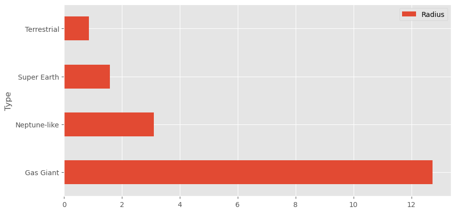

```python
types.plot(kind='barh', y='Radius');
```

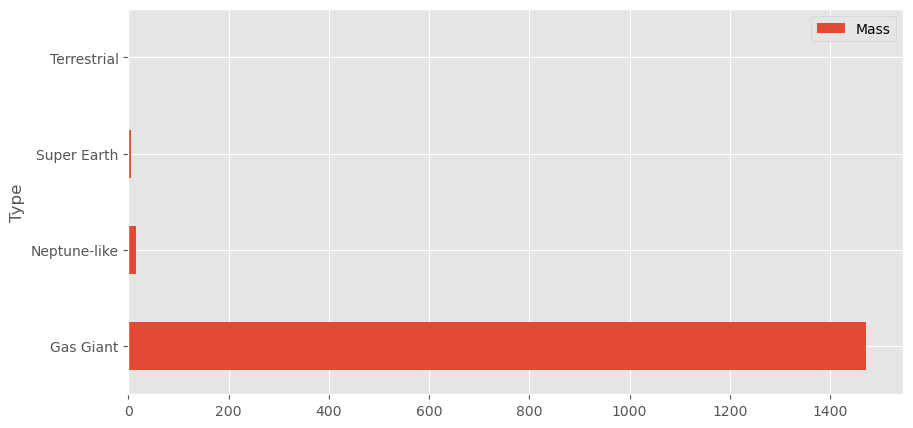

```python
types.plot(kind='barh', y='Mass');
```

- It looks like the `'Gas Giant'`s are aptly named!

[figure not shown]

### Bar charts

- Bar charts visualize the relationship between a categorical variable and a numerical variable.
- In a bar chart...
  - The thickness and spacing of bars is arbitrary.
  - The order of the categorical labels doesn't matter.
- To create one from a DataFrame `df`, use

  ```
  df.plot(
    kind='barh',
    x=categorical_column_name,
    y=numerical_column_name
  )
  ```

- The **"h"** in `'barh'` stands for **"horizontal"**.
  - It's easier to read labels this way.
- Note that in the previous chart, we set `y='Mass'` even though mass is measured by x-axis length.

### Bar charts and sorting

What are the most popular `'Detection'` methods for discovering exoplanets?

```python
# Count how many exoplanets are discovered by each detection method.
popular_detection = exo.groupby('Detection').count()
popular_detection
```

| Detection | Distance | Magnitude | Type | Year | Mass | Radius |
| --- | --- | --- | --- | --- | --- | --- |
| Astrometry | 1 | 1 | 1 | 1 | 1 | 1 |
| Direct Imaging | 50 | 50 | 50 | 50 | 50 | 50 |
| Disk Kinematics | 1 | 1 | 1 | 1 | 1 | 1 |
| ... | ... | ... | ... | ... | ... | ... |
| Radial Velocity | 1019 | 1019 | 1019 | 1019 | 1019 | 1019 |
| Transit | 3914 | 3914 | 3914 | 3914 | 3914 | 3914 |
| Transit Timing Variations | 23 | 23 | 23 | 23 | 23 | 23 |

11 rows × 6 columns

```python
# Give columns more meaningful names and eliminate redundancy.
popular_detection = (popular_detection.assign(Count=popular_detection.get('Distance'))
                                      .get(['Count'])
                                      .sort_values(by='Count', ascending=False)
                    )
popular_detection
```

| Detection | Count |
| --- | --- |
| Transit | 3914 |
| Radial Velocity | 1019 |
| Direct Imaging | 50 |
| ... | ... |
| Astrometry | 1 |
| Disk Kinematics | 1 |
| Pulsar Timing | 1 |

11 rows × 1 columns

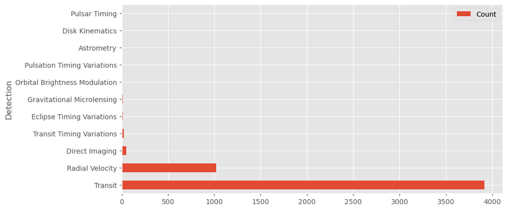

```python
# Notice that the bars appear in the opposite order relative to the DataFrame.
popular_detection.plot(kind='barh', y='Count');
```

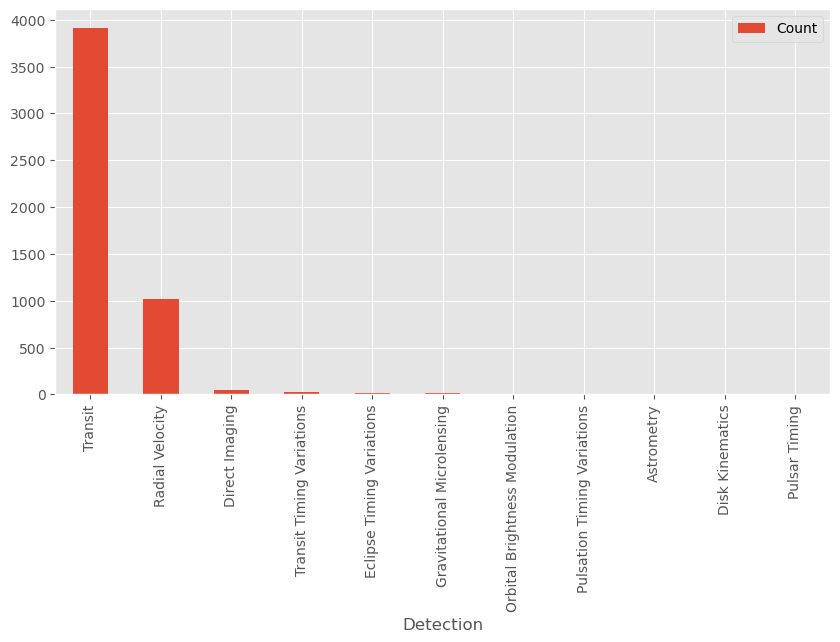

```python
# Change "barh" to "bar" to get a vertical bar chart.
# These are harder to read, but the bars do appear in the same order as the DataFrame.
popular_detection.plot(kind='bar', y='Count');
```

### Multiple plots on the same axes

Can we look at both the average `'Magnitude'` and the average `'Radius'` for each `'Type'` at the same time?

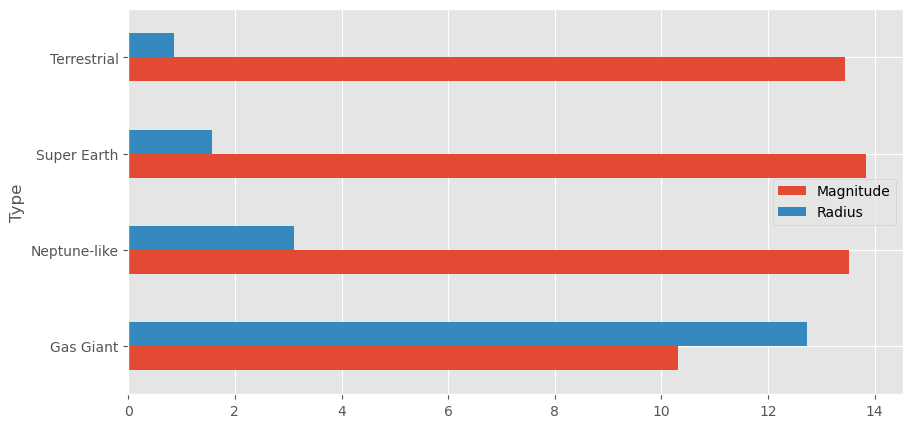

```python
types.get(['Magnitude', 'Radius']).plot(kind='barh');
```

How did we do that?

### Overlaying plots

When calling `.plot`, if we omit the `y=column_name` argument, **all other columns** are plotted.

```python
types
```

| Type | Distance | Magnitude | Year | Mass | Radius |
| --- | --- | --- | --- | --- | --- |
| Gas Giant | 1096.40 | 10.30 | 2013.73 | 1472.39 | 12.74 |
| Neptune-like | 2189.02 | 13.52 | 2016.59 | 15.28 | 3.11 |
| Super Earth | 1916.26 | 13.85 | 2016.43 | 5.81 | 1.58 |
| Terrestrial | 1373.60 | 13.45 | 2016.37 | 1.62 | 0.85 |

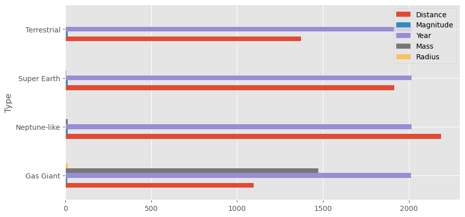

```python
types.plot(kind='barh');
```

### Selecting multiple columns at once

- To select multiple columns, use `.get([column_1, ..., column_k])`.
- Passing a list of column labels to `.get` returns a DataFrame.
  - `.get([column_name])` will return a DataFrame with just one column!

```python
types
```

| Type | Distance | Magnitude | Year | Mass | Radius |
| --- | --- | --- | --- | --- | --- |
| Gas Giant | 1096.40 | 10.30 | 2013.73 | 1472.39 | 12.74 |
| Neptune-like | 2189.02 | 13.52 | 2016.59 | 15.28 | 3.11 |
| Super Earth | 1916.26 | 13.85 | 2016.43 | 5.81 | 1.58 |
| Terrestrial | 1373.60 | 13.45 | 2016.37 | 1.62 | 0.85 |

```python
types.get(['Magnitude', 'Radius'])
```

| Type | Magnitude | Radius |
| --- | --- | --- |
| Gas Giant | 10.30 | 12.74 |
| Neptune-like | 13.52 | 3.11 |
| Super Earth | 13.85 | 1.58 |
| Terrestrial | 13.45 | 0.85 |

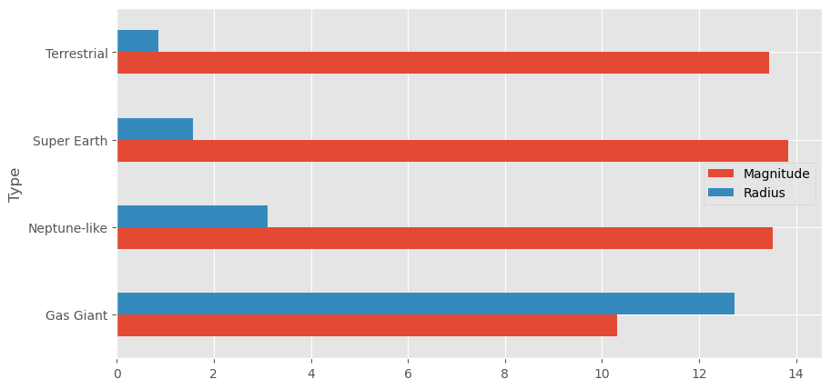

```python
types.get(['Magnitude', 'Radius']).plot(kind='barh');
```

## Summary

### Summary

- Visualizations make it easy to extract patterns from datasets.
- There are two main types of variables: categorical and numerical.
- The types of the variables we're visualizing inform our choice of which type of visualization to use.
- Today, we looked at scatter plots, line plots, and bar charts.
- **Next time**: histograms.